# Complete Guide to KMeansClusterer

Variable Clustering by Maximizing Within-Cluster Homogeneity

M2RClust Team

2025-12-02

## Introduction

The `KMeansClusterer` is a **variable clustering** algorithm (not observations) that groups variables into homogeneous clusters. Unlike classical K-Means which partitions individuals, this algorithm partitions the columns of a dataset.

### Algorithm Principle

Cluster homogeneity is measured by the **proportion of variance explained by its first principal component**. The algorithm iterates between:

1. **Update centers**: compute the 1st principal component (PC1) of each cluster
2. **Reassign variables**: each variable joins the cluster with which it has the highest association (R² for quantitative, η² for qualitative)

### Use Cases

- Interpretable dimensionality reduction
- Identification of correlated variable groups
- Data preparation for multivariate analyses
- Selection of representative variables per cluster

## Installation and Loading

```r
library(M2RClust)
```

## Example Data

We use the `mtcars` dataset which contains 11 variables describing 32 automobiles.

```r
data(mtcars)
str(mtcars)
```

```
#> 'data.frame':    32 obs. of  11 variables:
#>  $ mpg : num  21 21 22.8 21.4 18.7 18.1 14.3 24.4 22.8 19.2 ...
#>  $ cyl : num  6 6 4 6 8 6 8 4 4 6 ...
#>  $ disp: num  160 160 108 258 360 ...
#>  $ hp  : num  110 110 93 110 175 105 245 62 95 123 ...
#>  $ drat: num  3.9 3.9 3.85 3.08 3.15 2.76 3.21 3.69 3.92 3.92 ...
#>  $ wt  : num  2.62 2.88 2.32 3.21 3.44 ...
#>  $ qsec: num  16.5 17 18.6 19.4 17 ...
#>  $ vs  : num  0 0 1 1 0 1 0 1 1 1 ...
#>  $ am  : num  1 1 1 0 0 0 0 0 0 0 ...
#>  $ gear: num  4 4 4 3 3 3 3 4 4 4 ...
#>  $ carb: num  4 4 1 1 2 1 4 2 2 4 ...
```

```r
# Correlation overview (numeric columns only)
round(cor(mtcars[, sapply(mtcars, is.numeric)]), 2)
```

```
#>        mpg   cyl  disp    hp  drat    wt  qsec    vs    am  gear  carb
#> mpg   1.00 -0.85 -0.85 -0.78  0.68 -0.87  0.42  0.66  0.60  0.48 -0.55
#> cyl  -0.85  1.00  0.90  0.83 -0.70  0.78 -0.59 -0.81 -0.52 -0.49  0.53
#> disp -0.85  0.90  1.00  0.79 -0.71  0.89 -0.43 -0.71 -0.59 -0.56  0.39
#> hp   -0.78  0.83  0.79  1.00 -0.45  0.66 -0.71 -0.72 -0.24 -0.13  0.75
#> drat  0.68 -0.70 -0.71 -0.45  1.00 -0.71  0.09  0.44  0.71  0.70 -0.09
#> wt   -0.87  0.78  0.89  0.66 -0.71  1.00 -0.17 -0.55 -0.69 -0.58  0.43
#> qsec  0.42 -0.59 -0.43 -0.71  0.09 -0.17  1.00  0.74 -0.23 -0.21 -0.66
#> vs    0.66 -0.81 -0.71 -0.72  0.44 -0.55  0.74  1.00  0.17  0.21 -0.57
#> am    0.60 -0.52 -0.59 -0.24  0.71 -0.69 -0.23  0.17  1.00  0.79  0.06
#> gear  0.48 -0.49 -0.56 -0.13  0.70 -0.58 -0.21  0.21  0.79  1.00  0.27
#> carb -0.55  0.53  0.39  0.75 -0.09  0.43 -0.66 -0.57  0.06  0.27  1.00
```

## Basic Usage

### Creating and Fitting the Model

```r
# Create the clusterer
clusterer <- KMeansClusterer$new(
  data = mtcars,
  n_clusters = 3,
  standardize = TRUE,
  seed = 42
)

# Fit the model
clusterer$fit()

# Display results
clusterer$print()
```

```
#> Variable Clusterer
#>   3 clusters (sizes: 3, 4, 4)
#>   Convergence after 2 iterations (init: homogeneity++, runs=6/10 - early stop)
#>   Global homogeneity: 0.829
#>
#> Variable assignments:
#>  variable cluster
#>       mpg       3
#>       cyl       3
#>      disp       3
#>        hp       2
#>      drat       1
#>        wt       3
#>      qsec       2
#>        vs       2
#>        am       1
#>      gear       1
#>      carb       2
```

### Detailed Summary

```r
clusterer$summary()
```

```
#> =================================================
#> Variable Clustering
#> =================================================
#>
#> Configuration:
#>   - Number of clusters: 3
#>   - Number of variables: 11
#>   - Number of observations: 32
#>   - Standardize: YES
#>   - Initialization method: homogeneity++
#>   - Initialization runs: 6 / 10 (early stopped)
#>   - Iterations (best run): 2 / 100
#>   - Tolerance: 1.00e-04
#>
#>   - Global homogeneity: 0.829
#>   - Interpretation: Proportion of variance explained by PC1 within clusters
#>   - Range: [0, 1] where 1 = perfect homogeneity
#>
#> Cluster Sizes:
#>   Cluster 1: 3 variables
#>   Cluster 2: 4 variables
#>   Cluster 3: 4 variables
#>
#> Within-Cluster Homogeneity:
#>   Cluster 1: 0.824 (n=3 vars)
#>     First dimension explains 82.4% of cluster variance
#>   Cluster 2: 0.769 (n=4 vars)
#>     First dimension explains 76.9% of cluster variance
#>   Cluster 3: 0.893 (n=4 vars)
#>     First dimension explains 89.3% of cluster variance
#>
#> =================================================
```

### Retrieving Assignments

```r
results <- clusterer$get_results()
print(results)
```

```
#>    variable cluster
#> 1       mpg       3
#> 2       cyl       3
#> 3      disp       3
#> 4        hp       2
#> 5      drat       1
#> 6        wt       3
#> 7      qsec       2
#> 8        vs       2
#> 9        am       1
#> 10     gear       1
#> 11     carb       2
```

```r
# Table by cluster
for (k in 1:clusterer$n_clusters) {
  vars <- results$variable[results$cluster == k]
  cat(sprintf("\nCluster %d: %s\n", k, paste(vars, collapse = ", ")))
}
```

```
#>
#> Cluster 1: drat, am, gear
#>
#> Cluster 2: hp, qsec, vs, carb
#>
#> Cluster 3: mpg, cyl, disp, wt
```

## Initialization Methods

The `KMeansClusterer` offers three initialization methods:

### 1. Homogeneity++ (default)

Similar to K-Means++, selects diversified initial variables.

```r
clust_hpp <- KMeansClusterer$new(
  data = mtcars,
  n_clusters = 3,
  init_method = "homogeneity++",
  seed = 42
)
clust_hpp$fit()
cat("Homogeneity (homogeneity++):", round(clust_hpp$get_homogeneity(), 4), "\n")
```

```
#> Homogeneity (homogeneity++): 0.8291
```

### 2. Correlation (hierarchical)

Uses hierarchical clustering on the correlation-based dissimilarity matrix.

```r
clust_cor <- KMeansClusterer$new(
  data = mtcars,
  n_clusters = 3,
  init_method = "correlation",
  seed = 42
)
clust_cor$fit()
cat("Homogeneity (correlation):", round(clust_cor$get_homogeneity(), 4), "\n")
```

```
#> Homogeneity (correlation): 0.8291
```

### 3. Random

Simple random initialization.

```r
clust_rand <- KMeansClusterer$new(
  data = mtcars,
  n_clusters = 3,
  init_method = "random",
  n_init = 20,  # More attempts since less stable
  seed = 42
)
clust_rand$fit()
cat("Homogeneity (random):", round(clust_rand$get_homogeneity(), 4), "\n")
```

```
#> Homogeneity (random): 0.8291
```

### Comparing Methods

```r
cat("\n=== Initialization Methods Comparison ===\n")
```

```
#>
#> === Initialization Methods Comparison ===
```

```r
cat(sprintf("homogeneity++ : %.4f (runs: %d)\n",
            clust_hpp$get_homogeneity(), clust_hpp$get_actual_runs()))
```

```
#> homogeneity++ : 0.8291 (runs: 6)
```

```r
cat(sprintf("correlation   : %.4f (runs: %d)\n",
            clust_cor$get_homogeneity(), clust_cor$get_actual_runs()))
```

```
#> correlation   : 0.8291 (runs: 1)
```

```r
cat(sprintf("random        : %.4f (runs: %d)\n",
            clust_rand$get_homogeneity(), clust_rand$get_actual_runs()))
```

```
#> random        : 0.8291 (runs: 7)
```

## Visualizations

### Correlation Circle

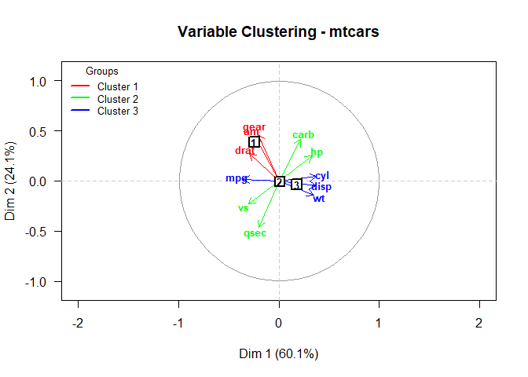

Correlation circle with clusters

```r
plot_clustering_2d(clusterer,
                   main = "Variable Clustering - mtcars",
                   show_centers = TRUE,
                   show_labels = TRUE)
```

### Correlation Heatmap

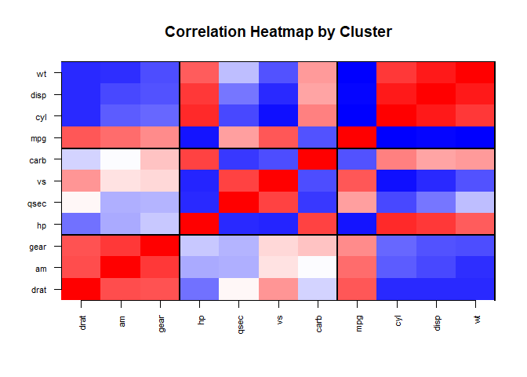

Correlation heatmap ordered by cluster

```r
plot_correlation_heatmap(clusterer, reorder = TRUE)
```

### Cluster Quality

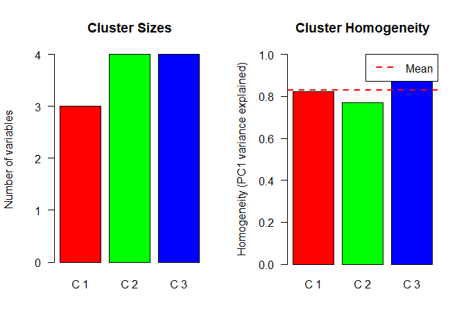

Cluster size and homogeneity

```r
quality <- plot_cluster_quality(clusterer)
```

```r
print(quality)
```

```
#> $sizes
#> [1] 3 4 4
#>
#> $homogeneity
#> [1] 0.82391 0.76946 0.89260
```

### Network Graph

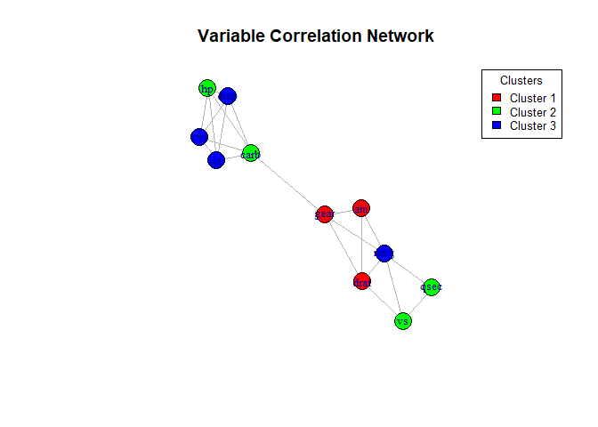

Correlation network between variables

```r
# Requires the igraph package
if (requireNamespace("igraph", quietly = TRUE)) {
  plot_network_graph(clusterer, threshold = 0.5, layout = "fruchterman.reingold")
}
```

### Scree Plot by Cluster

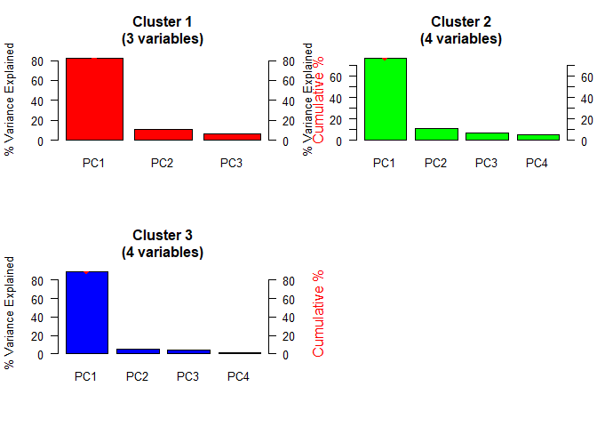

Variance explained by component in each cluster

```r
plot_scree_by_cluster(clusterer)
```

## Prediction on New Variables

The `KMeansClusterer` allows projecting new (supplementary) variables onto the existing clustering.

```r
# Create new variables (simulated)
set.seed(123)
new_vars <- data.frame(
  NewVar1 = mtcars$mpg + rnorm(32, sd = 2),  # Correlated with mpg
  NewVar2 = mtcars$hp * 0.8 + rnorm(32, sd = 10)  # Correlated with hp
)

# Predict clusters
predictions <- clusterer$predict(new_vars, return_scores = TRUE)
print(predictions)
```

```
#>   variable cluster    score_1   score_2   score_3
#> 1  NewVar1       3 0.40225250 0.4199879 0.8270659
#> 2  NewVar2       2 0.09118607 0.8294934 0.6424098
```

### Visualization with Supplementary Variables

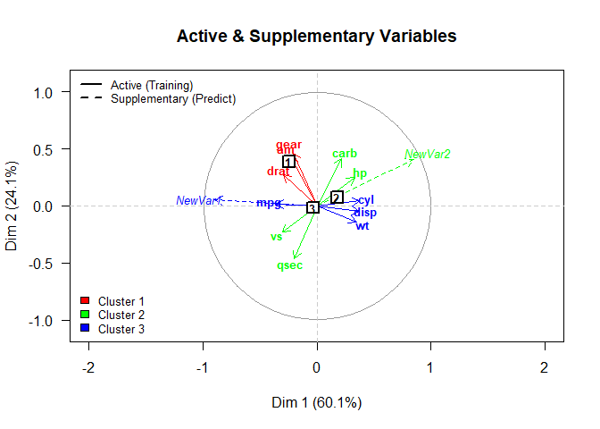

Correlation circle with supplementary variables

```r
plot_clustering_with_supp(clusterer)
```

## Selecting the Number of Clusters

### Elbow Method

```
#> Calculating elbow method...
#>   K = 2...
#>   K = 3...
#>   K = 4...
#>   K = 5...
#>   K = 6...
#>   K = 7...
#>   K = 8...
```

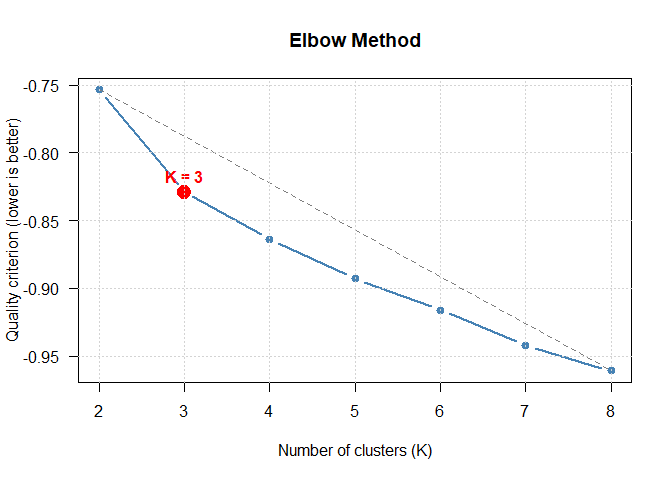

Elbow method

```
#>
#> K suggested by elbow method: 3
cat("\nSuggested K (Elbow):", elbow_res$suggested_k, "\n")
#>
#> Suggested K (Elbow): 3
```

```r
elbow_res <- elbow_method(
  KMeansClusterer,
  mtcars,
  k_range = 2:8,
  plot = TRUE,
  standardize = TRUE,
  seed = 42
)
```

### Silhouette Method

```
#> Calculating silhouette method...
#>   K = 2...
#>   K = 3...
#>   K = 4...
#>   K = 5...
#>   K = 6...
#>   K = 7...
#>   K = 8...
```

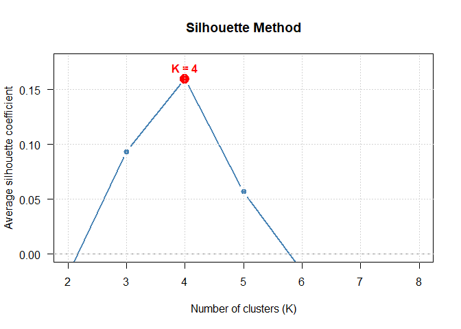

Silhouette method

```
#>
#> Suggested K by silhouette method: 4
#> Silhouette coefficient: 0.159
cat("\nSuggested K (Silhouette):", sil_res$suggested_k, "\n")
#>
#> Suggested K (Silhouette): 4
```

```r
sil_res <- silhouette_method(
  KMeansClusterer,
  mtcars,
  k_range = 2:8,
  plot = TRUE,
  standardize = TRUE,
  seed = 42
)
```

### Calinski-Harabasz Index

```
#> Calculating Calinski-Harabasz (Pseudo-F)...
#>   K = 2...
#>   K = 3...
#>   K = 4...
#>   K = 5...
#>   K = 6...
#>   K = 7...
#>   K = 8...
```

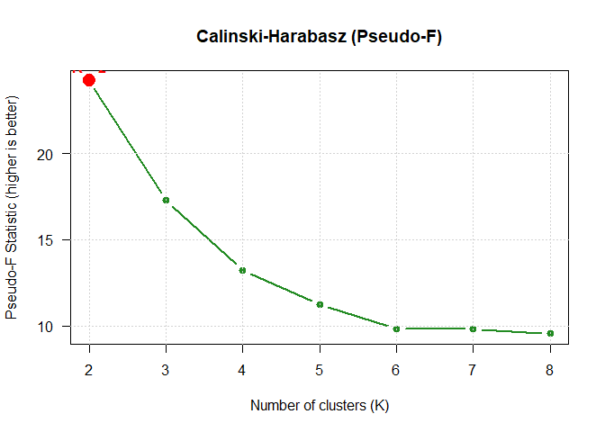

Calinski-Harabasz index (Pseudo-F)

```
#>
#> K suggested by Calinski-Harabasz: 2
#> Pseudo-F score: 24.205
cat("\nSuggested K (Calinski-Harabasz):", ch_res$suggested_k, "\n")
#>
#> Suggested K (Calinski-Harabasz): 2
```

```r
ch_res <- calinski_harabasz_method(
  KMeansClusterer,
  mtcars,
  k_range = 2:8,
  plot = TRUE,
  standardize = TRUE,
  seed = 42
)
```

### Comparing All Methods

```
#> ========================================
#> COMPARISON OF K SELECTION METHODS
#> ========================================
#>
#>
#> 1. ELBOW METHOD
#> -------------------
#> Calculating elbow method...
#>   K = 2...
#>   K = 3...
#>   K = 4...
#>   K = 5...
#>   K = 6...
#>   K = 7...
#>   K = 8...
#>
#> K suggested by elbow method: 3
#>
#> 2. SILHOUETTE METHOD
#> ---------------------------
#> Calculating silhouette method...
#>   K = 2...
#>   K = 3...
#>   K = 4...
#>   K = 5...
#>   K = 6...
#>   K = 7...
#>   K = 8...
#>
#> Suggested K by silhouette method: 4
#> Silhouette coefficient: 0.159
#>
#> 3. CALINSKI-HARABASZ METHOD (PSEUDO-F)
#> ----------------------------------------
#> Calculating Calinski-Harabasz (Pseudo-F)...
#>   K = 2...
#>   K = 3...
#>   K = 4...
#>   K = 5...
#>   K = 6...
#>   K = 7...
#>   K = 8...
```

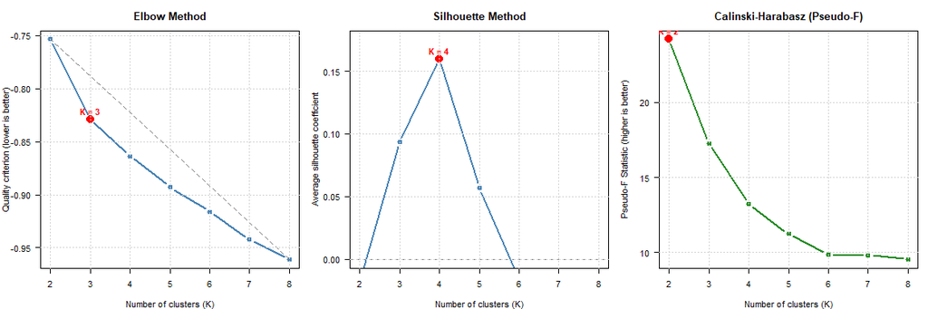

Comparison of K selection methods

```
#>
#> K suggested by Calinski-Harabasz: 2
#> Pseudo-F score: 24.205
#>
#> ========================================
#> SUMMARY OF RECOMMENDATIONS
#> ========================================
#> Elbow Method:           K = 3
#> Silhouette Method:      K = 4
#> Calinski-Harabasz:      K = 2
#>
#> No consensus (all methods differ). Using Elbow method: K = 3
#> ========================================
cat("\n=== Consensus ===\n")
#>
#> === Consensus ===
cat("Recommended K:", comparison$consensus_k, "\n")
#> Recommended K: 3
```

```r
comparison <- compare_k_selection_methods(
  KMeansClusterer,
  mtcars,
  k_range = 2:8,
  plot = TRUE,
  standardize = TRUE,
  seed = 42
)
```

## Mixed Data (Quantitative + Qualitative)

The `KMeansClusterer` supports mixed data through PCAmix.

```r
# Create mixed data
mtcars_mixed <- mtcars[, c("mpg", "cyl", "hp", "wt", "qsec")]
mtcars_mixed$cyl <- as.factor(mtcars_mixed$cyl)
mtcars_mixed$gear <- as.factor(mtcars$gear)
mtcars_mixed$am <- as.factor(mtcars$am)

str(mtcars_mixed)
```

```
#> 'data.frame':    32 obs. of  7 variables:
#>  $ mpg : num  21 21 22.8 21.4 18.7 18.1 14.3 24.4 22.8 19.2 ...
#>  $ cyl : Factor w/ 3 levels "4","6","8": 2 2 1 2 3 2 3 1 1 2 ...
#>  $ hp  : num  110 110 93 110 175 105 245 62 95 123 ...
#>  $ wt  : num  2.62 2.88 2.32 3.21 3.44 ...
#>  $ qsec: num  16.5 17 18.6 19.4 17 ...
#>  $ gear: Factor w/ 3 levels "3","4","5": 2 2 2 1 1 1 1 2 2 2 ...
#>  $ am  : Factor w/ 2 levels "0","1": 2 2 2 1 1 1 1 1 1 1 ...
```

```
#> Variable Clusterer
#>   3 clusters (sizes: 1, 4, 2)
#>   Convergence after 1 iterations (init: homogeneity++, runs=7/10 - early stop)
#>   Global homogeneity: 0.743
#>
#> Variable assignments:
#>  variable cluster
#>       mpg       2
#>       cyl       1
#>        hp       3
#>        wt       2
#>      qsec       3
#>      gear       2
#>        am       2
```

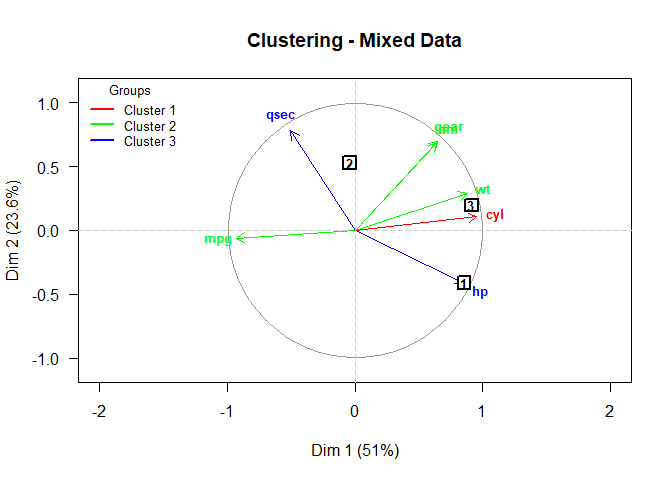

```r
# Clustering on mixed data
if (requireNamespace("PCAmixdata", quietly = TRUE)) {
  clusterer_mixed <- KMeansClusterer$new(
    data = mtcars_mixed,
    n_clusters = 3,
    standardize = TRUE,
    seed = 42
  )
  clusterer_mixed$fit()
  clusterer_mixed$print()

  # Visualization
  plot_clustering_2d(clusterer_mixed, main = "Clustering - Mixed Data")
}
```

## Advanced Parameters

### Convergence Control

```r
clusterer_advanced <- KMeansClusterer$new(
  data = mtcars,
  n_clusters = 3,
  standardize = TRUE,
  max_iter = 200,      # Maximum iterations per run
  tol = 1e-6,          # Stricter convergence tolerance
  n_init = 30,         # More initializations
  init_method = "homogeneity++",
  seed = 42
)
clusterer_advanced$fit()

cat("Iterations:", clusterer_advanced$get_iterations(), "\n")
```

```
#> Iterations: 2
```

```r
cat("Runs performed:", clusterer_advanced$get_actual_runs(), "/",
    clusterer_advanced$get_n_init(), "\n")
```

```
#> Runs performed: 6 / 30
```

```r
cat("Homogeneity:", round(clusterer_advanced$get_homogeneity(), 4), "\n")
```

```
#> Homogeneity: 0.8291
```

### Early Stopping

The algorithm automatically stops if the same optimum is found twice (likely global optimum).

```r
# With many initializations, early stopping is often triggered
clusterer_es <- KMeansClusterer$new(
  data = mtcars,
  n_clusters = 3,
  n_init = 50,
  seed = 42
)
clusterer_es$fit()

if (clusterer_es$get_actual_runs() < 50) {
  cat("Early stopping triggered after", clusterer_es$get_actual_runs(), "runs\n")
}
```

```
#> Early stopping triggered after 6 runs
```

## Best Practices

### 1. Standardization

Always standardize data (default) unless variables are already on the same scale.

### 2. Choosing K

- Use `compare_k_selection_methods()` for an overview
- Prioritize interpretability over mathematical optimum

### 3. Reproducibility

Always set a seed (`seed`) for reproducible results.

### 4. Validation

Verify that clusters make business sense by examining: - Member variables in each cluster - Cluster homogeneity - Intra and inter-cluster correlations

## Metrics and Interpretation

### Homogeneity

Cluster homogeneity measures the proportion of variance explained by PC1: - **1.0**: Perfect homogeneity (all variables perfectly correlated) - **< 0.5**: Heterogeneous cluster (variables weakly related to each other)

```r
cat("Homogeneity by cluster:\n")
```

```
#> Homogeneity by cluster:
```

```r
homog <- clusterer$get_cluster_homogeneity()
for (k in 1:length(homog)) {
  cat(sprintf("  Cluster %d: %.3f\n", k, homog[k]))
}
```

```
#>   Cluster 1: 0.824
#>   Cluster 2: 0.769
#>   Cluster 3: 0.893
```

```r
cat(sprintf("\nGlobal homogeneity (weighted average): %.3f\n",
            clusterer$get_homogeneity()))
```

```
#>
#> Global homogeneity (weighted average): 0.829
```

## Conclusion

The `KMeansClusterer` is a powerful tool for grouping correlated variables. It is particularly useful for:

- Exploring the structure of multivariate datasets
- Interpretable dimensionality reduction
- Identifying thematic groups of variables

For data with a natural hierarchical structure, also consider the `DivisiveClusterer` presented in the dedicated vignette.

## References

- Vigneau, E., & Qannari, E. M. (2003). Clustering of variables around latent components. *Communications in Statistics-Simulation and Computation*, 32(4), 1131-1150.
- Chavent, M., Kuentz, V., Liquet, B., & Saracco, L. (2012). ClustOfVar: An R Package for the Clustering of Variables. *Journal of Statistical Software*, 50(13), 1-16.